# Data Analysis Project: Knee Replacement Surgery Outcomes

Analysis Project

Gitika Jain (gitikaj2)

Heather Sewak (hsewak2)

Ionel Miu (imiu2)

Jared Michael Colbert (jaredc2)

December 14, 2016

# Knee Replacement Surgery Outcome

## Introduction

This research aims to determine if the postoperative function of a total knee replacement recipient can be modeled based on anthropomorphic data and details of the surgical procedure. We decided to carry out testing on models with two postoperative scoring systems as the response variable. The first score is the “Surgeon’s Score” which measures more objective postoperative metrics about the condition of the replaced knee following surgery. These metrics include: how straight or how flexed the patient can make their knee, how well aligned the knee appears when inspecting from a frontal perspective and how much laxity or separation can be achieved by placing the lower leg under tension. Finally, the patient is asked about the overall pain they experience with the knee. The resulting score is a value between 0-100 with 80-100 being an excellent result.

The second score we model is the “Patient’s Score” which is generated by three questions: how far are they able to walk, how well can they navigate stairs and do they require any walking aids (crutches, cane, etc).

We hope to create a model that can predict each of the scores based on a variety of categorical and numeric predictors.

## Background information

This data has been collected from a Southern California Hospital in collaboration with the Shiley Center for Orthopedic Research. The data is used for both clinical research and postoperative monitoring of implant survivorship. All patient specific information has been removed from the data so it adheres to the Health Insurance Portability and Accountability Act (HIPAA).

## Statement

We hope to determine the impact a particular surgeon or the type of implants used has on the patient’s outcome after surgery. We are also interested in exploring the potential relationship between anthropomorphic factors and the patient’s postoperative satisfaction. Finally, we would like to understand if the considerable expense of computer navigation in knee replacement leads to better postoperative scores. Nevertheless, we keep our option opened to investigate other aspects that were not ‘visible’ or never thought about it but might reveal themselves as we move on with the project.

Here we may consider *KneeScore_Surgeon* or *KneeScore_Patient* as response and *Age, Gendar, Weight, Height, BMI, Race, Side, Manufacturer* as predictors. *Gendar, Race, Side and Manufacturer* are some of the categorical predictors and *Age, Height, Weight and BMI* are numerical predictors.

```r
knee = read.csv('knees.csv')
knee$Surgeon = as.factor(knee$Surgeon)
knee$Year = as.factor(knee$Year)
```

### Functions for model evaluation

```r
#Function to plot various plots as QQPlot, Fitted vs Residual Plot.
plots = function(model) {
  par(mfcol=c(1,3))
  qqnorm(resid(model), col = red, pch = 16)
  qqline(resid(model), col = lightblue, lwd = 2)
  plot(fitted(model), resid(model), xlab = 'Fitted Values', ylab = 'Residuals', main = 'Fitted vs. Residuals Plot', col = purple, pch = 16)
  abline(h = 0, col = green, lwd = 2)
  hist(resid(model), col = blue, main = 'Histogram of Residuals', xlab = 'Residuals')
}

#Function to calculate various statistics which we use to evaluate the model
evaluate = function(model){
  # Run each of the tests
  lambda = 1.000001 # this is a hack so the function will return a CrossValidation score - HatValues of 1.0 are causing a division by zero error.
  shapiroTest = shapiro.test(resid(model))
  bpTest = bptest(model)
  rSquared = summary(model)$r.squared
  adjRSquared = summary(model)$adj.r.squared
  loocv = sqrt(mean((resid(model) / (lambda - hatvalues(model))) ^ 2))
  large_hat = sum(hatvalues(model) > 2 * mean(hatvalues(model)))
  large_resid = sum(rstandard(model)[abs(rstandard(model)) > 2]) / (length(rstandard(model) + lambda))
  large_cooks = sum(cooks.distance(model) > 4 / length(cooks.distance(model)))

  # Collect tests in dataframe
  values = data.frame(Result = c(prettyNum(shapiroTest$p.value), prettyNum(bpTest$p.value), prettyNum(rSquared), prettyNum(adjRSquared),prettyNum(loocv), prettyNum(large_hat), prettyNum(large_cooks)))
  rowNames = data.frame(Test = c('Shapiro Wilk pvalue', 'Breusch-Pagan pvalue', 'R Squared', 'Adj R Squared', 'Cross Validation', 'Large Hat Values', 'Influential'))

  summary_output = cbind(rowNames, values)
  show(summary_output)
  plots(model)
}
# find and remove all influential values and return the resulting dataframe
removeInfluential = function(model, data){
  cooks = which(cooks.distance(model) > 4 / length(cooks.distance(model)))
  newData = data[-cooks , ]
  return(newData)
}

# identify all influential data points
IdentifyInfluential = function(model, data){
  cooks = which(cooks.distance(model) > 4 / length(cooks.distance(model)))
  return(index_)
}

# find large hat values, subtract them from the dataframe and return the dataframe
removeLargeHatValues = function(model, data){
  largeHat = which(hatvalues(model) > 2 * mean(hatvalues(model)))
  newData = data[-largeHat, ]
  return(newData)
}

# Calculate the RMSE
rmse  = function(actual, predicted) {  sqrt(mean((actual - predicted) ^ 2))}
```

### Knee Score Surgeon

Before moving onto the formal analysis of our data set, we started by performing visual inspection by plotting dependencies among our the variables. The main focus was to look for any visual relationship between `KneeScore_Surgeon, KneeScore_Patient` and the rest of variables. Our choise was to use `scatterplotMatrix` from `car` package as it is plots regression lines along with the actual data.

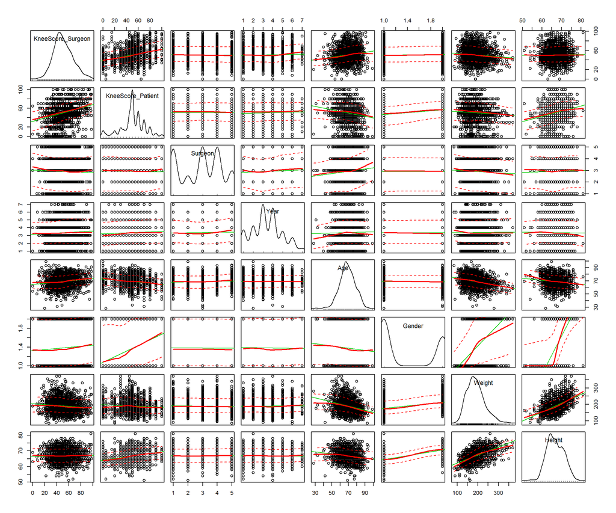

```r
scatterplotMatrix(~ KneeScore_Surgeon + KneeScore_Patient + Surgeon + Year + Age + Gender + Weight + Height, span=0.7, data=knee)
```

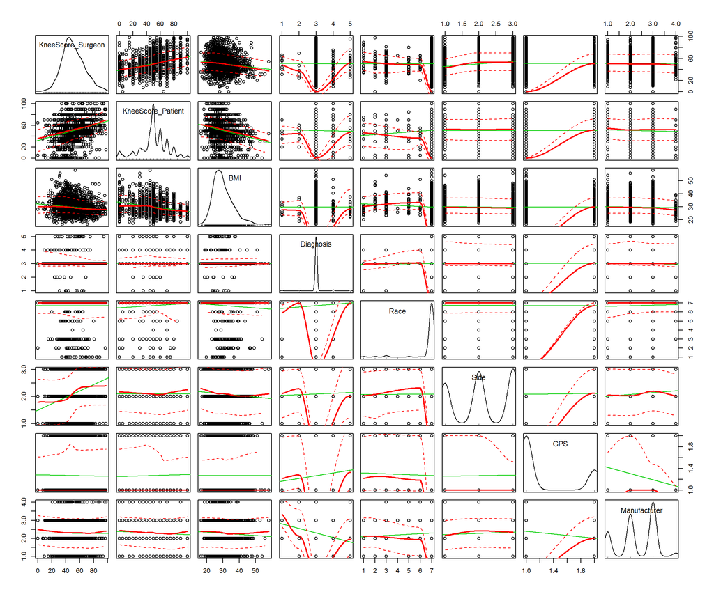

```r
scatterplotMatrix(~ KneeScore_Surgeon + KneeScore_Patient + BMI + Diagnosis + Race + Side + GPS + Manufacturer, span=0.7, data=knee)
```

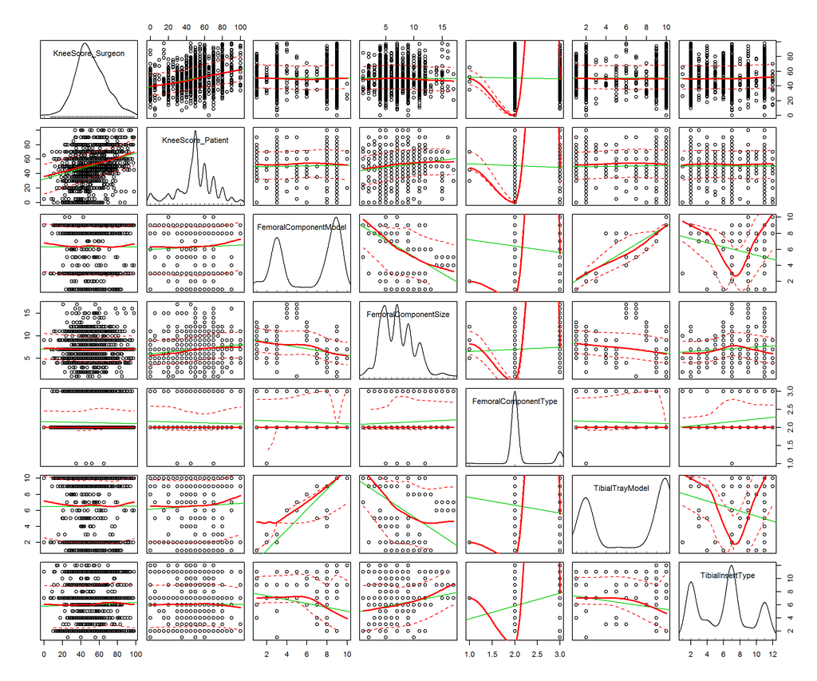

```r
scatterplotMatrix(~ KneeScore_Surgeon + KneeScore_Patient + FemoralComponentModel + FemoralComponentSize + FemoralComponentType + TibialTrayModel + TibialInsertType, span=0.7, data=knee)
```

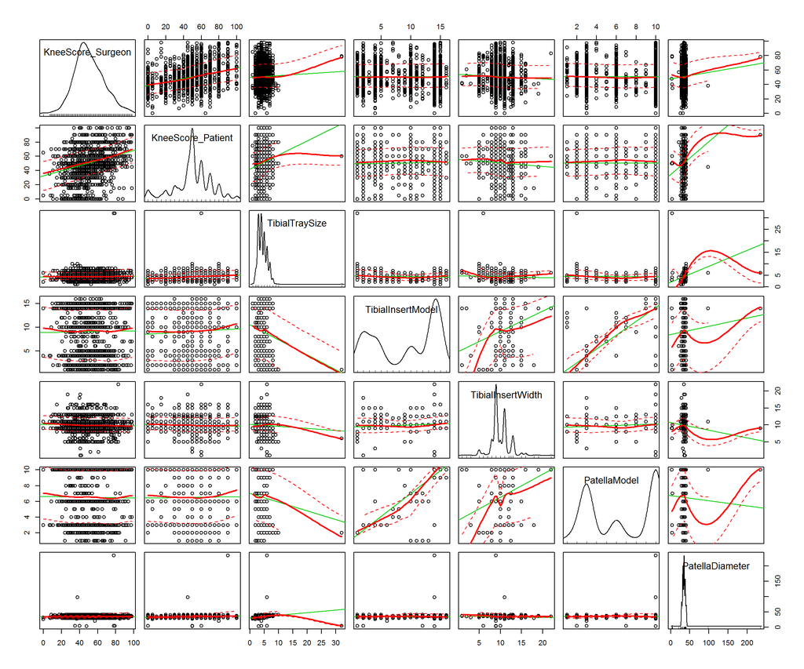

```r
scatterplotMatrix(~ KneeScore_Surgeon + KneeScore_Patient + TibialTraySize + TibialInsertModel + TibialInsertWidth + PatellaModel + PatellaDiameter, span=0.7, data=knee)
```

**Comments:** Based on the above graphics, `KneeScore_Surgeon, KneeScore_Patient` seems to behave similarly across all variable. This is expected as both, Surgeon and Patient, should be in consensus in regards to he success or quality of a procedure.

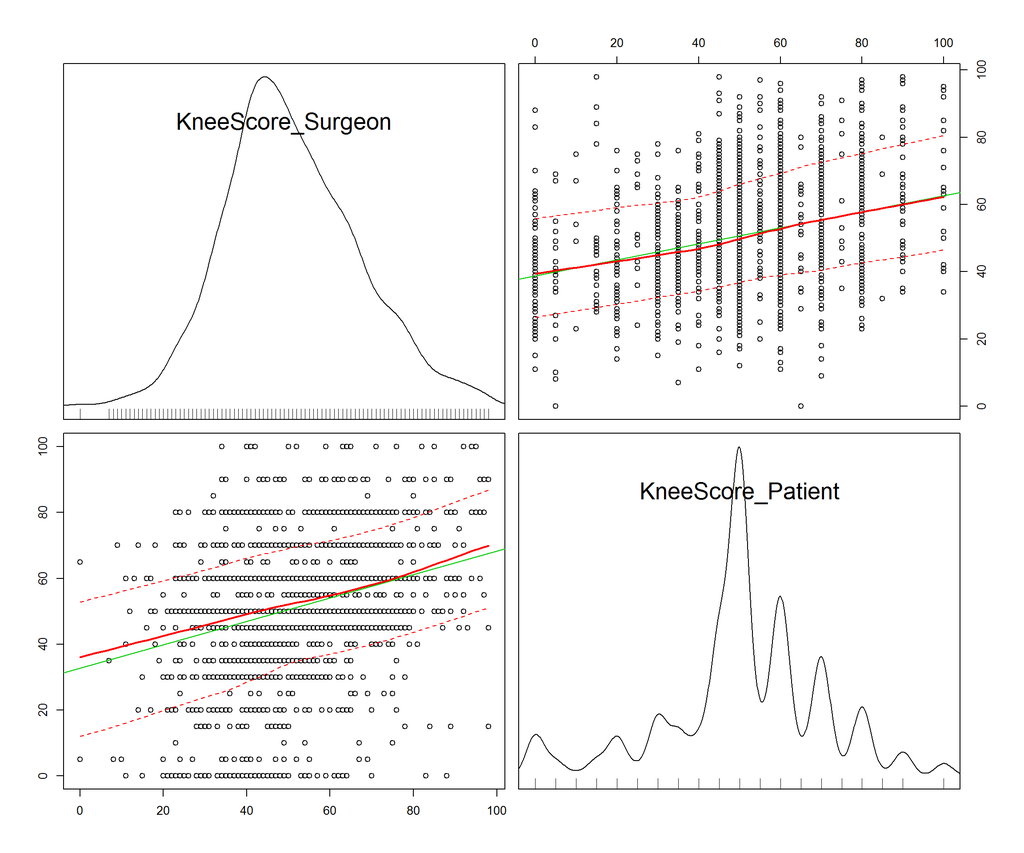

```r
scatterplotMatrix(~ KneeScore_Surgeon + KneeScore_Patient, span=0.7, data=knee)
```

The distribution of `KneeScore_Surgeon` which reflects the score of a procedure assigned be the `Surgeon` is unimodal distribution compared to a multimodel distribution of `KneeScore_Patient`, which is the score assigned by `Patient`. Our explanation of this is that `Surgeon` assgigns any number between 1 and 100 without any discreation whereas `Patient` has a tendency to round up the score to the nearest fifth(Ex: 5, 10, 35, 50, etc)

Begin by fitting a full additive model as a baseline and evaluating.

```r
sample_idx = sample(1:nrow(knee), 1500)
train_data = knee[sample_idx, ]
test_data = knee[-sample_idx, ]
surgeon_full_additive_model = lm(KneeScore_Surgeon ~ ., data = train_data)
evaluate(surgeon_full_additive_model)
```

```
##                   Test       Result
## 1  Shapiro Wilk pvalue 2.371562e-05
## 2 Breusch-Pagan pvalue    0.4095621
## 3            R Squared      0.25903
## 4        Adj R Squared    0.2094562
## 5     Cross Validation     14.67071
## 6     Large Hat Values          164
## 7          Influential           NA
```

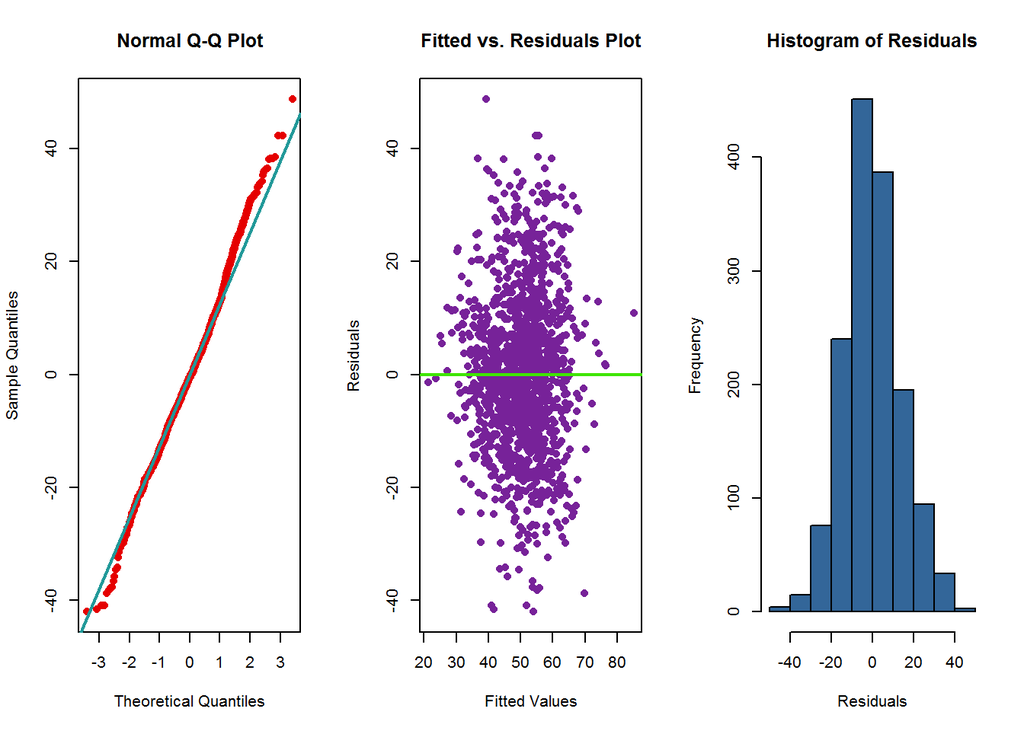

The baseline model has many large hat values. Let’s try to understand why.

```r
largeHat = which(hatvalues(surgeon_full_additive_model) > (2 * mean(hatvalues(surgeon_full_additive_model))))
unique(largeHat)
```

```
##   [1]    1    5   13   14   41   44   52   53   57   64   79   81   91   93
##  [15]   98  100  110  123  128  139  145  152  159  161  168  176  186  192
##  [29]  199  209  231  238  251  253  260  267  270  273  275  291  297  305
##  [43]  320  335  336  341  347  355  359  361  371  378  392  397  406  407
##  [57]  412  422  433  443  458  468  477  485  496  498  501  506  533  565
##  [71]  566  575  579  580  582  590  600  619  620  629  634  635  652  661
##  [85]  715  725  728  732  744  749  756  761  765  773  777  791  795  798
##  [99]  803  813  821  832  840  842  847  867  877  878  881  893  894  948
## [113]  949  986  991  996 1013 1020 1021 1039 1040 1047 1064 1065 1072 1074
## [127] 1082 1095 1104 1151 1173 1177 1183 1190 1236 1239 1250 1255 1268 1285
## [141] 1292 1298 1301 1307 1319 1330 1366 1379 1385 1395 1405 1406 1411 1422
## [155] 1424 1430 1438 1446 1449 1453 1455 1461 1476 1480
```

```r
print(knee[612, ])
```

```
##     Surgeon Year Age Gender Weight Height  BMI      Diagnosis     Race
## 612       3 2012  41 Female    182     66 29.4 Osteoarthritis Hispanic
##          Side KneeScore_Surgeon KneeScore_Patient GPS Manufacturer
## 612 Bilateral                39                80 Yes  DePuy (J&J)
##     FemoralComponentModel FemoralComponentSize FemoralComponentType
## 612                 Sigma                   4N   cruciate retaining
##     TibialTrayModel TibialTraySize TibialInsertModel TibialInsertWidth
## 612       PFC Sigma              3         PFC Sigma                 8
##         TibialInsertType            PatellaModel PatellaDiameter
## 612 curved,Fixed bearing Oval Dome Patella 3-peg              35
```

```r
print(knee[1496, ])
```

```
##      Surgeon Year Age Gender Weight Height   BMI      Diagnosis  Race
## 1496       4 2013  66 Female    158     64 27.14 Osteoarthritis White
##       Side KneeScore_Surgeon KneeScore_Patient GPS   Manufacturer
## 1496 Right                74                50  No Smith & Nephew
##      FemoralComponentModel FemoralComponentSize FemoralComponentType
## 1496                Legion                   6N   cruciate retaining
##      TibialTrayModel TibialTraySize TibialInsertModel TibialInsertWidth
## 1496      Genesis II              5        Genesis II                 9
##      TibialInsertType PatellaModel PatellaDiameter
## 1496        high flex   Genesis II              29
```

After inspection of the rows that represent the large hat values it seems that there are a preponderance of values that are either errant entries or valid, but rare entries. For example, the `Race` predictor has only two entries for `Mid-East Arabian` and the `FemoralComponentSize` entry of ‘8+’ is errant. First we will attempt to remove the predictors that seem to be prone to errant or rare values and later we will remove the high leverage values directly.

We attempted several model iterations with transformations of both the response and predictors as well as large all two-way interaction models none of which proved helpful in predicting the response. The models with many interactions took both substantial time and computing resources to fit and were suspect of overfitting. We pick up here with model eight which was the first of the promising models. The interested reader can find earlier attempted model in the appendix.

```r
surgeon_model_eight = lm(KneeScore_Surgeon ~ . - Diagnosis - Race - TibialInsertType - FemoralComponentModel - PatellaModel - TibialTrayModel - TibialTraySize - FemoralComponentType, data = train_data)
evaluate(surgeon_model_eight)
```

```
##                   Test       Result
## 1  Shapiro Wilk pvalue 0.0002577709
## 2 Breusch-Pagan pvalue    0.0679178
## 3            R Squared    0.2309883
## 4        Adj R Squared    0.2016977
## 5     Cross Validation     14.58059
## 6     Large Hat Values           98
## 7          Influential           NA
```

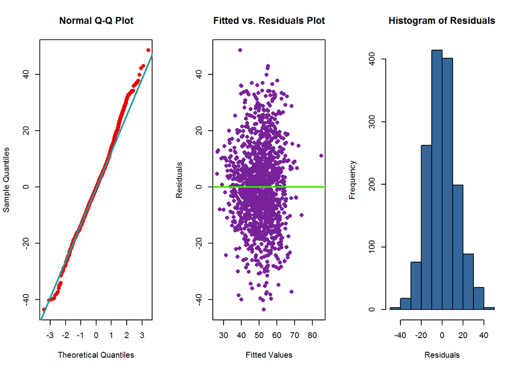

```r
anova(surgeon_model_eight, surgeon_full_additive_model)
```

```
## Analysis of Variance Table
##
## Model 1: KneeScore_Surgeon ~ (Surgeon + Year + Age + Gender + Weight +
##     Height + BMI + Diagnosis + Race + Side + KneeScore_Patient +
##     GPS + Manufacturer + FemoralComponentModel + FemoralComponentSize +
##     FemoralComponentType + TibialTrayModel + TibialTraySize +
##     TibialInsertModel + TibialInsertWidth + TibialInsertType +
##     PatellaModel + PatellaDiameter) - Diagnosis - Race - TibialInsertType -
##     FemoralComponentModel - PatellaModel - TibialTrayModel -
##     TibialTraySize - FemoralComponentType
## Model 2: KneeScore_Surgeon ~ Surgeon + Year + Age + Gender + Weight +
##     Height + BMI + Diagnosis + Race + Side + KneeScore_Patient +
##     GPS + Manufacturer + FemoralComponentModel + FemoralComponentSize +
##     FemoralComponentType + TibialTrayModel + TibialTraySize +
##     TibialInsertModel + TibialInsertWidth + TibialInsertType +
##     PatellaModel + PatellaDiameter
##   Res.Df    RSS Df Sum of Sq      F  Pr(>F)
## 1   1444 295076
## 2   1405 284316 39     10760 1.3634 0.06821 .
## ---
## Signif. codes:  0 '***' 0.001 '**' 0.01 '*' 0.05 '.' 0.1 ' ' 1
```

```r
surgeon_model_back_aic = step(surgeon_full_additive_model, direction = "backward", trace = 0)
evaluate(surgeon_model_back_aic)
```

```
##                   Test       Result
## 1  Shapiro Wilk pvalue 0.0001287098
## 2 Breusch-Pagan pvalue 0.0001996482
## 3            R Squared    0.2262338
## 4        Adj R Squared    0.2077353
## 5     Cross Validation     14.42053
## 6     Large Hat Values          124
## 7          Influential           74
```

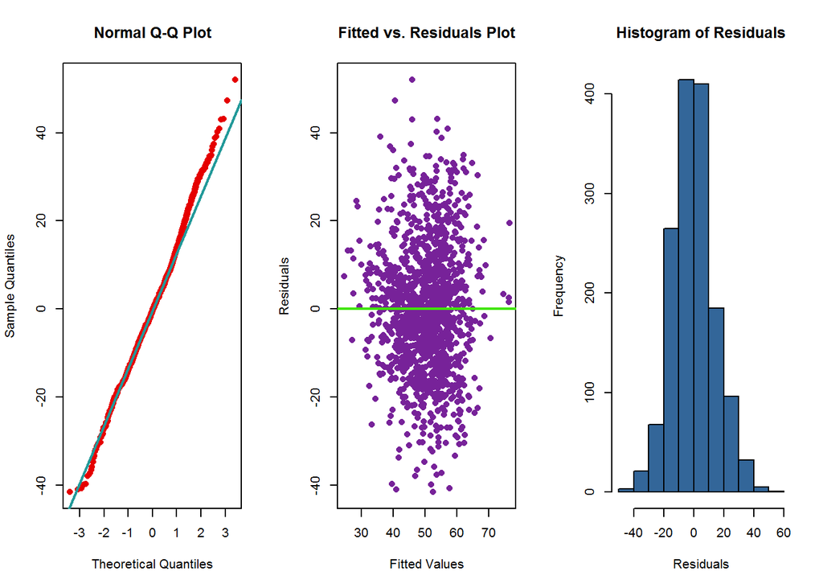

```r
anova(surgeon_model_back_aic, surgeon_full_additive_model)
```

```
## Analysis of Variance Table
##
## Model 1: KneeScore_Surgeon ~ Surgeon + Year + Age + Diagnosis + Side +
##     KneeScore_Patient + FemoralComponentSize + TibialTraySize
## Model 2: KneeScore_Surgeon ~ Surgeon + Year + Age + Gender + Weight +
##     Height + BMI + Diagnosis + Race + Side + KneeScore_Patient +
##     GPS + Manufacturer + FemoralComponentModel + FemoralComponentSize +
##     FemoralComponentType + TibialTrayModel + TibialTraySize +
##     TibialInsertModel + TibialInsertWidth + TibialInsertType +
##     PatellaModel + PatellaDiameter
##   Res.Df    RSS Df Sum of Sq     F Pr(>F)
## 1   1464 296900
## 2   1405 284316 59     12584 1.054 0.3671
```

Removing the Influential observations and running AIC again-

```r
clean_dataset_aic = removeInfluential(surgeon_model_back_aic, train_data)
surgeon_full_additive_model_clean = lm(KneeScore_Surgeon ~ ., data = clean_dataset_aic)
surgeon_model_aic_clean = step(surgeon_full_additive_model_clean, direction = "backward", trace = 0)
```

Utilize a Bayesian Information Criterion approach and evaluate the selected model.

```r
n = length(resid(surgeon_full_additive_model))
surgeon_model_back_bic = step(surgeon_full_additive_model, direction = "backward", k = log(n), trace = 0)
evaluate(surgeon_model_back_bic)
```

```
##                   Test       Result
## 1  Shapiro Wilk pvalue  0.001070551
## 2 Breusch-Pagan pvalue 0.0004448697
## 3            R Squared    0.1787501
## 4        Adj R Squared    0.1765528
## 5     Cross Validation     14.54573
## 6     Large Hat Values           74
## 7          Influential           85
```

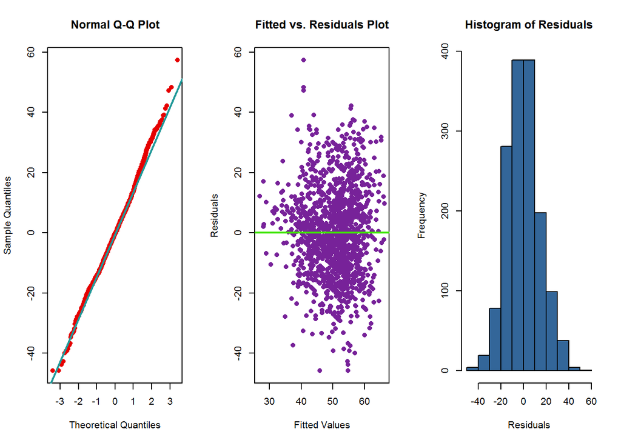

```r
coef(surgeon_model_back_bic)
```

```
##       (Intercept)               Age          SideLeft         SideRight
##        12.4392453         0.2678222         9.2192450         8.7012974
## KneeScore_Patient
##         0.2580325
```

```r
anova(surgeon_model_back_bic, surgeon_full_additive_model)
```

```
## Analysis of Variance Table
##
## Model 1: KneeScore_Surgeon ~ Age + Side + KneeScore_Patient
## Model 2: KneeScore_Surgeon ~ Surgeon + Year + Age + Gender + Weight +
##     Height + BMI + Diagnosis + Race + Side + KneeScore_Patient +
##     GPS + Manufacturer + FemoralComponentModel + FemoralComponentSize +
##     FemoralComponentType + TibialTrayModel + TibialTraySize +
##     TibialInsertModel + TibialInsertWidth + TibialInsertType +
##     PatellaModel + PatellaDiameter
##   Res.Df    RSS Df Sum of Sq      F    Pr(>F)
## 1   1495 315120
## 2   1405 284316 90     30804 1.6914 9.253e-05 ***
## ---
## Signif. codes:  0 '***' 0.001 '**' 0.01 '*' 0.05 '.' 0.1 ' ' 1
```

The resulting BIC model scores marginally better in Cross Validation though the anova results clearly prefer the full additive model.

Lets try the interaction between the predictors which we got in the model selected by Backward BIC.

```r
surgeon_model_back_bic_int = lm(KneeScore_Surgeon ~ Age * Side * KneeScore_Patient, data = train_data)
evaluate(surgeon_model_back_bic_int)
```

```
##                   Test       Result
## 1  Shapiro Wilk pvalue 0.0002512949
## 2 Breusch-Pagan pvalue 0.0003680799
## 3            R Squared    0.2048819
## 4        Adj R Squared     0.199004
## 5     Cross Validation     14.39763
## 6     Large Hat Values          135
## 7          Influential           90
```

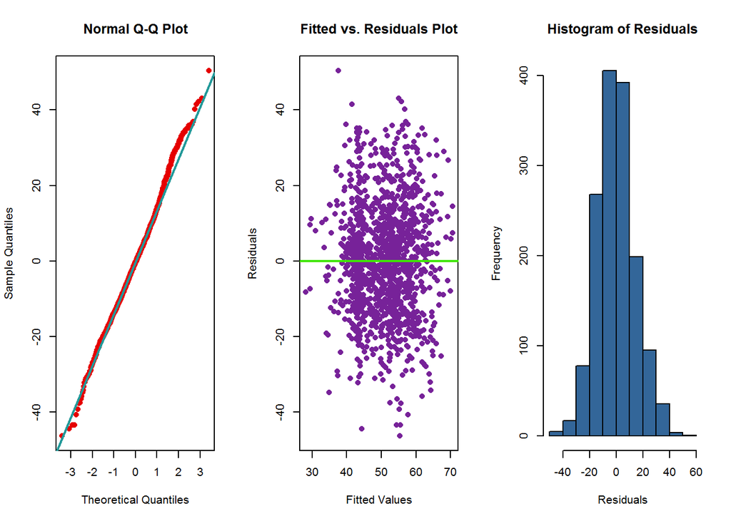

```r
anova(surgeon_model_back_bic_int, surgeon_full_additive_model)
```

```
## Analysis of Variance Table
##
## Model 1: KneeScore_Surgeon ~ Age * Side * KneeScore_Patient
## Model 2: KneeScore_Surgeon ~ Surgeon + Year + Age + Gender + Weight +
##     Height + BMI + Diagnosis + Race + Side + KneeScore_Patient +
##     GPS + Manufacturer + FemoralComponentModel + FemoralComponentSize +
##     FemoralComponentType + TibialTrayModel + TibialTraySize +
##     TibialInsertModel + TibialInsertWidth + TibialInsertType +
##     PatellaModel + PatellaDiameter
##   Res.Df    RSS Df Sum of Sq     F  Pr(>F)
## 1   1488 305093
## 2   1405 284316 83     20777 1.237 0.07771 .
## ---
## Signif. codes:  0 '***' 0.001 '**' 0.01 '*' 0.05 '.' 0.1 ' ' 1
```

```r
coef(surgeon_model_back_bic_int)
```

```
##                     (Intercept)                             Age
##                     -9.88985884                      0.75690475
##                        SideLeft                       SideRight
##                     29.57169601                     22.02482626
##               KneeScore_Patient                    Age:SideLeft
##                      0.92575766                     -0.50394085
##                   Age:SideRight           Age:KneeScore_Patient
##                     -0.41131259                     -0.01311244
##      SideLeft:KneeScore_Patient     SideRight:KneeScore_Patient
##                     -0.66392658                     -0.65077145
##  Age:SideLeft:KneeScore_Patient Age:SideRight:KneeScore_Patient
##                      0.01392280                      0.01388718
```

Perhaps removing some influential data points will assist in creating a better model. Next we remove influential points that satisfy the criteria for `Large Cook's Distance` values and evaluating BIC again.

```r
clean_dataset = removeInfluential(surgeon_model_back_bic, train_data)
surgeon_full_additive_model_clean = lm(KneeScore_Surgeon ~ ., data = clean_dataset)
surgeon_model_back_bic_clean = step(surgeon_full_additive_model_clean, direction = "backward", k = log(n), trace = 0)

evaluate(surgeon_model_back_bic_clean)
```

```
##                   Test       Result
## 1  Shapiro Wilk pvalue 5.450603e-05
## 2 Breusch-Pagan pvalue 2.682837e-05
## 3            R Squared    0.2244004
## 4        Adj R Squared    0.2222001
## 5     Cross Validation     12.59071
## 6     Large Hat Values           79
## 7          Influential           52
```

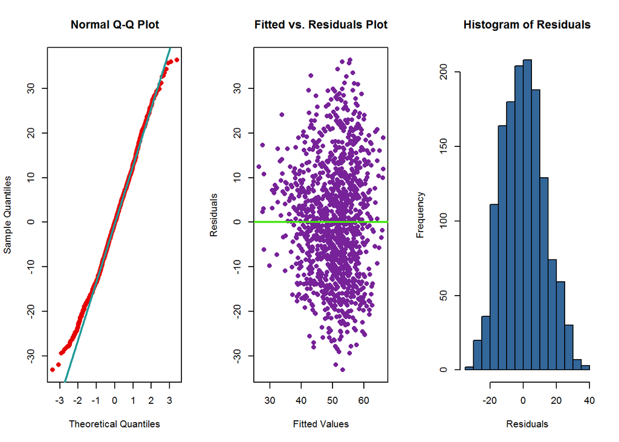

```r
anova(surgeon_model_back_bic_clean, surgeon_full_additive_model_clean)
```

```
## Analysis of Variance Table
##
## Model 1: KneeScore_Surgeon ~ Age + Side + KneeScore_Patient
## Model 2: KneeScore_Surgeon ~ Surgeon + Year + Age + Gender + Weight +
##     Height + BMI + Diagnosis + Race + Side + KneeScore_Patient +
##     GPS + Manufacturer + FemoralComponentModel + FemoralComponentSize +
##     FemoralComponentType + TibialTrayModel + TibialTraySize +
##     TibialInsertModel + TibialInsertWidth + TibialInsertType +
##     PatellaModel + PatellaDiameter
##   Res.Df    RSS Df Sum of Sq      F   Pr(>F)
## 1   1410 222820
## 2   1320 201720 90     21099 1.5341 0.001347 **
## ---
## Signif. codes:  0 '***' 0.001 '**' 0.01 '*' 0.05 '.' 0.1 ' ' 1
```

How about interaction on clean dataset-

```r
surgeon_model_back_bic_int_clean = lm(KneeScore_Surgeon ~ Age * Side * KneeScore_Patient, data = clean_dataset)
evaluate(surgeon_model_back_bic_int_clean)
```

```
##                   Test       Result
## 1  Shapiro Wilk pvalue 9.013721e-05
## 2 Breusch-Pagan pvalue 0.0005975228
## 3            R Squared    0.2399872
## 4        Adj R Squared    0.2340285
## 5     Cross Validation     12.51066
## 6     Large Hat Values          134
## 7          Influential           51
```

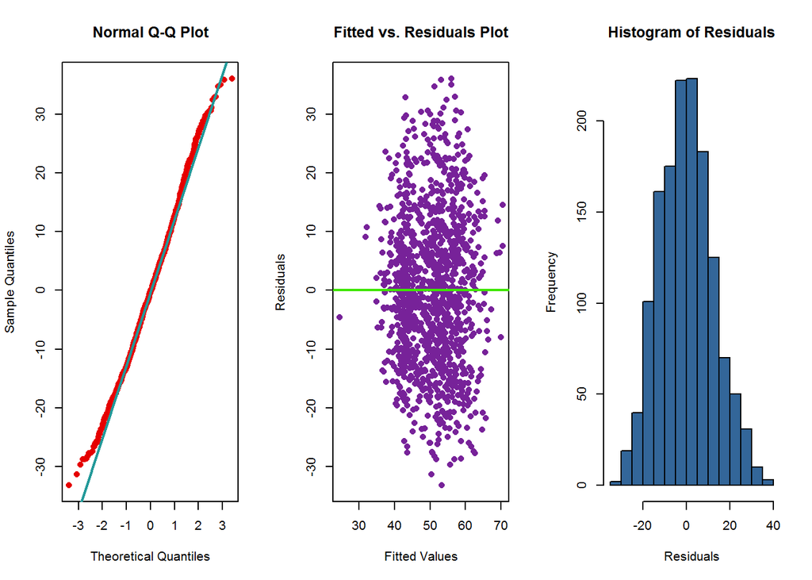

comparing BIC and Interaction Models

```r
anova(surgeon_model_back_bic_clean, surgeon_model_back_bic_int_clean)
```

```
## Analysis of Variance Table
##
## Model 1: KneeScore_Surgeon ~ Age + Side + KneeScore_Patient
## Model 2: KneeScore_Surgeon ~ Age * Side * KneeScore_Patient
##   Res.Df    RSS Df Sum of Sq      F   Pr(>F)
## 1   1410 222820
## 2   1403 218342  7    4477.9 4.1105 0.000176 ***
## ---
## Signif. codes:  0 '***' 0.001 '**' 0.01 '*' 0.05 '.' 0.1 ' ' 1
```

Next, we will evaluate the RMSE of the best performing models thus far.

| Model | Train RMSE | Test RMSE |
| --- | --- | --- |
| `Model All+` | 13.7675024 | 14.2582191 |
| `Model 8` | 14.025596 | 14.0968822 |
| `Model AIC` | 14.0688863 | 14.0231534 |
| `Model BIC` | 14.4941417 | 13.8126587 |
| `Model Int` | 14.2616796 | 13.777013 |
| `Model Clean All+` | 13.9129165 | 14.0854214 |
| `Model Clean AIC` | 14.1141528 | 14.0918752 |
| `Model Clean BIC` | 14.4971738 | 13.8333021 |
| `Model Clean Int` | 14.3374595 | 13.7637815 |

Interaction model gives the BEST RMSE also low Cross Validation and High $Adjusted R^2$, so we will consider this as the best model to predict the KneeScore_Surgeon.

### Knee Score Patient

Begin by fitting a full additive model as a baseline and evaluating.

```r
pat_full_additive_model = lm(KneeScore_Patient ~ ., data = knee)
evaluate(pat_full_additive_model)
```

```
##                   Test       Result
## 1  Shapiro Wilk pvalue 1.177599e-13
## 2 Breusch-Pagan pvalue     0.257962
## 3            R Squared     0.296855
## 4        Adj R Squared     0.261377
## 5     Cross Validation     17.00694
## 6     Large Hat Values          204
## 7          Influential           NA
```

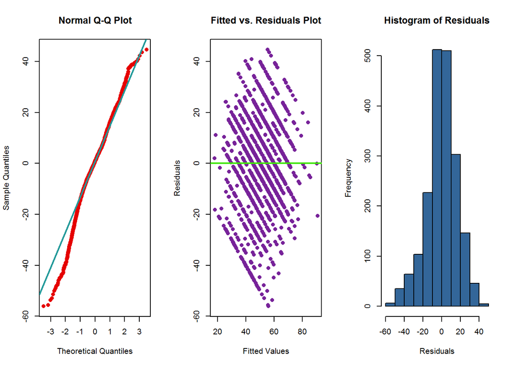

The baseline model has many large leverage values, which, upon inspection may be coming from several of the implant fields. Perhaps removing the suspect implant predictors will help improve the model.

```r
pat_model_eight = lm(KneeScore_Patient ~ . - Diagnosis - Race - TibialInsertType - FemoralComponentModel - PatellaModel - TibialTrayModel - TibialTraySize - FemoralComponentType, data = knee)
evaluate(pat_model_eight)
```

```
##                   Test       Result
## 1  Shapiro Wilk pvalue 2.572268e-14
## 2 Breusch-Pagan pvalue 0.0001090169
## 3            R Squared    0.2776021
## 4        Adj R Squared    0.2567126
## 5     Cross Validation     16.92618
## 6     Large Hat Values          125
## 7          Influential           NA
```

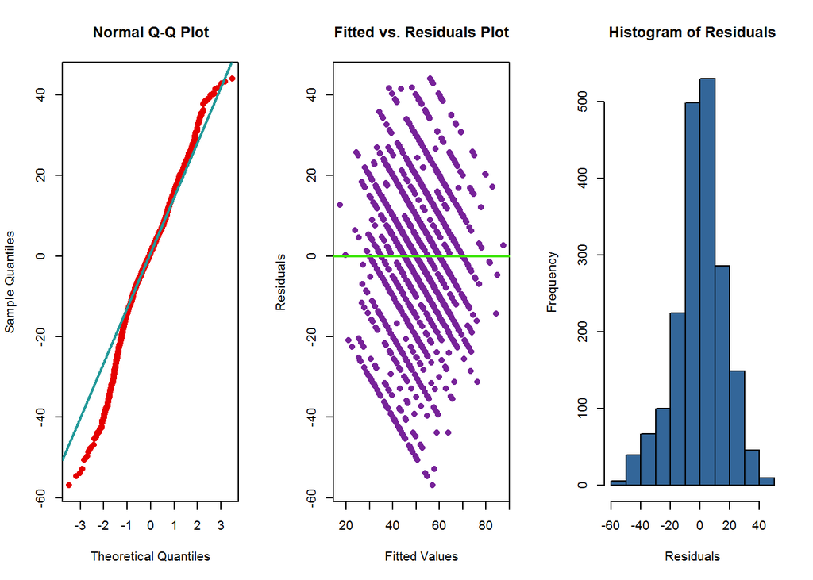

```r
anova(pat_model_eight, pat_full_additive_model)
```

```
## Analysis of Variance Table
##
## Model 1: KneeScore_Patient ~ (Surgeon + Year + Age + Gender + Weight +
##     Height + BMI + Diagnosis + Race + Side + KneeScore_Surgeon +
##     GPS + Manufacturer + FemoralComponentModel + FemoralComponentSize +
##     FemoralComponentType + TibialTrayModel + TibialTraySize +
##     TibialInsertModel + TibialInsertWidth + TibialInsertType +
##     PatellaModel + PatellaDiameter) - Diagnosis - Race - TibialInsertType -
##     FemoralComponentModel - PatellaModel - TibialTrayModel -
##     TibialTraySize - FemoralComponentType
## Model 2: KneeScore_Patient ~ Surgeon + Year + Age + Gender + Weight +
##     Height + BMI + Diagnosis + Race + Side + KneeScore_Surgeon +
##     GPS + Manufacturer + FemoralComponentModel + FemoralComponentSize +
##     FemoralComponentType + TibialTrayModel + TibialTraySize +
##     TibialInsertModel + TibialInsertWidth + TibialInsertType +
##     PatellaModel + PatellaDiameter
##   Res.Df    RSS Df Sum of Sq     F Pr(>F)
## 1   1902 532327
## 2   1863 518140 39     14187 1.308 0.0973 .
## ---
## Signif. codes:  0 '***' 0.001 '**' 0.01 '*' 0.05 '.' 0.1 ' ' 1
```

Utilize a Bayesian Information Criterion approach and evaluate the selected model.

```r
n = length(resid(pat_full_additive_model))
pat_model_back_bic = step(pat_full_additive_model, direction = "backward", k = log(n), trace = 0)
evaluate(pat_model_back_bic)
```

```
##                   Test       Result
## 1  Shapiro Wilk pvalue 2.427597e-15
## 2 Breusch-Pagan pvalue 7.235823e-07
## 3            R Squared    0.2424413
## 4        Adj R Squared    0.2405008
## 5     Cross Validation     16.93997
## 6     Large Hat Values          112
## 7          Influential          148
```

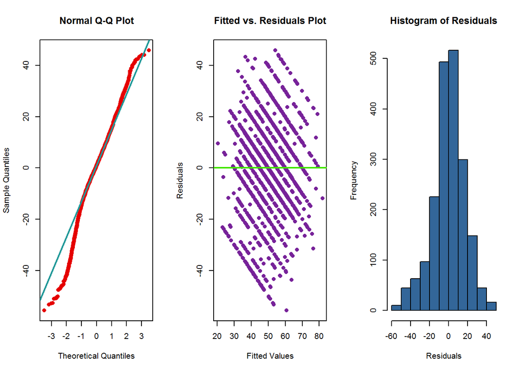

```r
anova(pat_model_back_bic, pat_full_additive_model)
```

```
## Analysis of Variance Table
##
## Model 1: KneeScore_Patient ~ Age + Gender + Weight + Height + KneeScore_Surgeon
## Model 2: KneeScore_Patient ~ Surgeon + Year + Age + Gender + Weight +
##     Height + BMI + Diagnosis + Race + Side + KneeScore_Surgeon +
##     GPS + Manufacturer + FemoralComponentModel + FemoralComponentSize +
##     FemoralComponentType + TibialTrayModel + TibialTraySize +
##     TibialInsertModel + TibialInsertWidth + TibialInsertType +
##     PatellaModel + PatellaDiameter
##   Res.Df    RSS Df Sum of Sq      F    Pr(>F)
## 1   1952 558236
## 2   1863 518140 89     40097 1.6199 0.0003004 ***
## ---
## Signif. codes:  0 '***' 0.001 '**' 0.01 '*' 0.05 '.' 0.1 ' ' 1
```

The resulting BIC model scores marginally better in Cross Validation though the anova results clearly prefer the full additive model.

Next, we will evaluate the RMSE of the best performing models thus far.

```r
options(warn=-1)
sample_idx = sample(1:nrow(knee), 1500)
train_data = knee[sample_idx, ]
test_data = knee[-sample_idx, ]

rmse  = function(actual, predicted) {  sqrt(mean((actual - predicted) ^ 2))}

pat_full_test = rmse(test_data$KneeScore_Patient, predict(pat_full_additive_model, test_data))
pat_full_train = rmse(train_data$KneeScore_Patient, predict(pat_full_additive_model, train_data))

pat_test_mod_8 = rmse(test_data$KneeScore_Patient, predict(pat_model_eight, test_data))
pat_train_mod_8 = rmse(train_data$KneeScore_Patient, predict(pat_model_eight, train_data))

pat_bic_test = rmse(test_data$KneeScore_Patient, predict(pat_model_back_bic, test_data))
pat_bic_train = rmse(train_data$KneeScore_Patient, predict(pat_model_back_bic, train_data))
```

[output not shown]

```r
new_dataframe = removeInfluential(pat_model_eight, knee)
pat_model_nine = lm(KneeScore_Patient ~ . - Diagnosis - Race - TibialInsertType - FemoralComponentModel - PatellaModel - TibialTrayModel - TibialTraySize - FemoralComponentType, data = new_dataframe)
evaluate(pat_model_nine)
```

```
##                   Test       Result
## 1  Shapiro Wilk pvalue 1.475761e-09
## 2 Breusch-Pagan pvalue  0.001662082
## 3            R Squared    0.3104628
## 4        Adj R Squared    0.2893819
## 5     Cross Validation     15.11494
## 6     Large Hat Values           97
## 7          Influential           NA
```

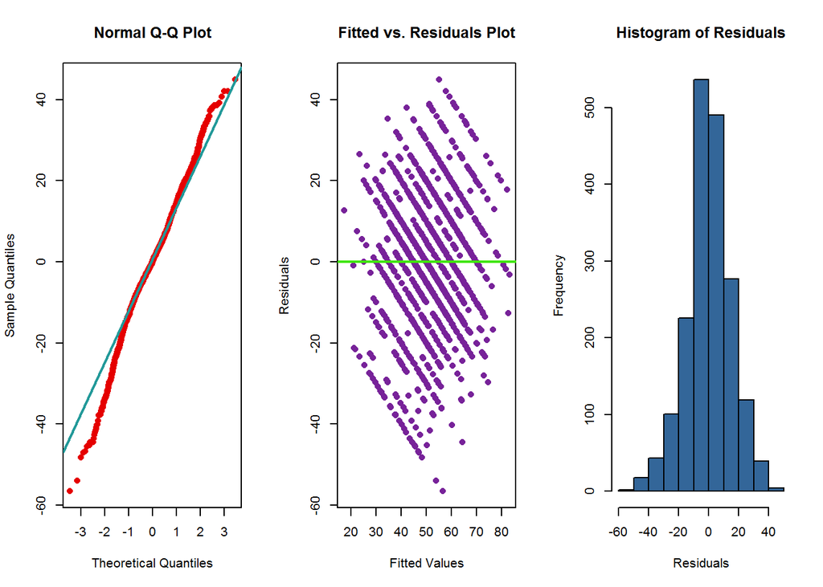

This does seem to be of moderate benefit in relation to Adjusted $R^2$ and Cross Validation.

We will evaluate the same model one again after removing the identified large hat values.

```r
remove_hat_dataframe = removeLargeHatValues(pat_model_nine, new_dataframe)
pat_model_ten = lm(KneeScore_Patient ~ . - Diagnosis - Race - TibialInsertType - FemoralComponentModel - PatellaModel - TibialTrayModel - TibialTraySize - FemoralComponentType, data = remove_hat_dataframe)
evaluate(pat_model_ten)
```

```
##                   Test       Result
## 1  Shapiro Wilk pvalue 3.905128e-08
## 2 Breusch-Pagan pvalue  0.002867139
## 3            R Squared    0.3047602
## 4        Adj R Squared    0.2893913
## 5     Cross Validation     15.40933
## 6     Large Hat Values           96
## 7          Influential           94
```

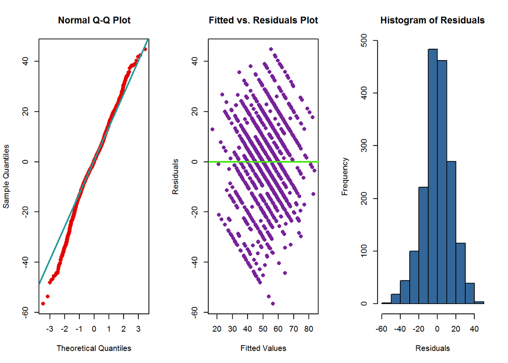

```r
n = length(resid(pat_model_ten))
pat_model_10_bic = step(pat_model_ten, direction = "backward", k = log(n), trace = 0)
evaluate(pat_model_10_bic)
```

```
##                   Test       Result
## 1  Shapiro Wilk pvalue 9.345871e-09
## 2 Breusch-Pagan pvalue  0.001236141
## 3            R Squared    0.2778953
## 4        Adj R Squared    0.2758345
## 5     Cross Validation     15.44057
## 6     Large Hat Values           92
## 7          Influential          124
```

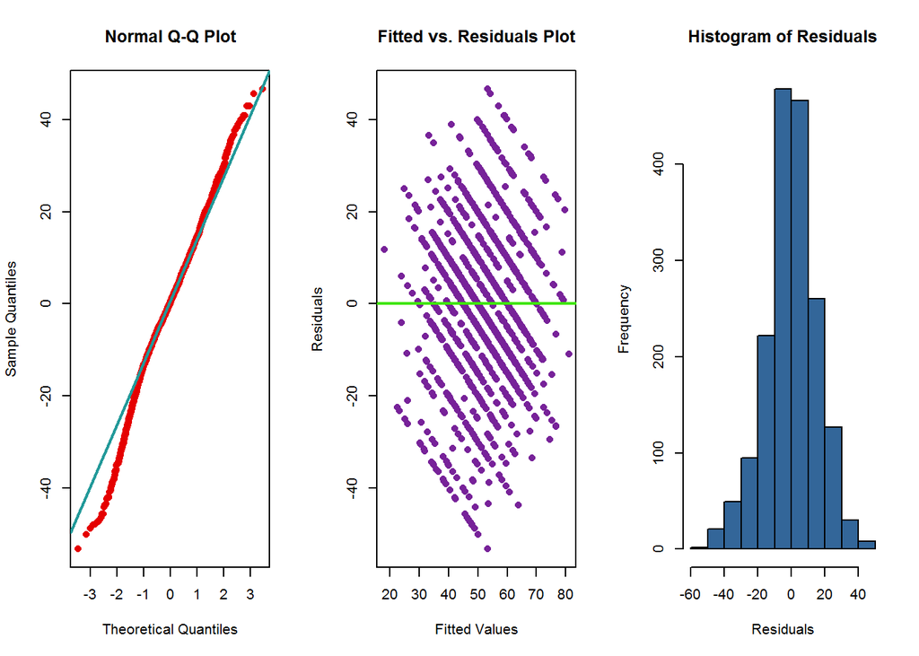

Despite the reduction in leveraged values the selected model is no better than preceding models.

```r
sample_idx_two = sample(1:nrow(remove_hat_dataframe), 1300)
train_data_two = remove_hat_dataframe[sample_idx_two, ]
test_data_two = remove_hat_dataframe[-sample_idx_two, ]

test_mod_10 = rmse(test_data_two$KneeScore_Patient, predict(pat_model_ten, train_data_two))
train_mod_10 = rmse(train_data_two$KneeScore_Patient, predict(pat_model_ten, train_data_two))

test_10_bic = rmse(test_data_two$KneeScore_Patient, predict(pat_model_10_bic, train_data_two))
train_10_bic = rmse(train_data_two$KneeScore_Patient, predict(pat_model_10_bic, train_data_two))
```

| Model | Train RMSE | Test RMSE |
| --- | --- | --- |
| `Model 10` | 15.2085464 | 20.1884815 |
| `Model 10 BIC` | 15.5109719 | 19.8858293 |

Interestingly, again the models fit on the dataset without leverages fares worse on test RMSE.

## Appendix

```r
# Warning: takes hours to fit
all_two_way_model = lm(KneeScore_Surgeon ~ .*., data = knee)
```

```r
# Warning...
n = length(resid(all_two_way_model))
model_one_bic_all_two_way = step(all_two_way_model, direction = 'backward', k = log(n), trace = 0)
```

```r
model_one_pat = lm(log(KneeScore_Patient) ~ ., data = knee)
model_one_surg = lm(log(KneeScore_Surgoen) ~ ., data = knee)
```

```r
model_two_exp_pat= lm(KneeScore_Patient^2 ~ ., data = knee)
model_two_exp_surg = lm(KneeScore_Surgeon^2 ~ ., data = knee)
```

```r
# replace all 0 values with the mean of the vector
temp = knee
temp$KneeScore_Patient[temp$KneeScore_Patient == 0] = mean(temp$KneeScore_Patient)

model_three = lm(KneeScore_Patient ~ ., data = temp)
evaluate(model_five)
```

```r
clean_temp_data = removeLargeHatValues(model_three, temp)
model_four = lm(KneeScore_Patient ~ ., data = clean_temp_data)
evaluate(model_four)
```

```r
pat_model = lm(KneeScore_Patient ~. , data = knee)
pat_model_back_aic = step(pat_model, direction = "backward", trace = 0)
pat_model_for_aic = step(pat_model, direction = "forward", trace = 0)
pat_model_both_aic = step(pat_model, direction = "both", trace = 0)

n = length(resid(pat_model))
pat_model_back_bic = step(pat_model, direction = "backward", k = log(n), trace = 0)
pat_model_for_bic = step(pat_model, direction = "forward", k = log(n), trace = 0)
pat_model_both_bic = step(pat_model, direction = "both", k = log(n), trace = 0)
```

```r
evaluate(pat_model)
```

```r
evaluate(pat_model_back_aic)
```

```r
evaluate(pat_model_for_aic)
```

```r
evaluate(pat_model_both_aic)
```

```r
## Adj.R.Squared: 0.24 - CrossValidation: 16.9
evaluate(pat_model_back_bic)
```

```r
evaluate(pat_model_for_bic)
```

```r
evaluate(pat_model_both_bic)
```

```r
## Remove large leverages
new_data = removeInfluential(pat_model, knee)
pat_model_without_large_leverages = lm(KneeScore_Patient ~ ., data = new_data)
evaluate(pat_model_without_large_leverages)
```

Removing the records with large hat values and refitting simply introduces more large hat values. What is unique about these rows of data?

```r
which(hatvalues(pat_model) == 1.0)
print(knee[17,])
print(knee[240,])
print(knee[638,])
print(knee[1093,])
print(knee[1775, ])
```

```r
pat_model_nine = lm(KneeScore_Patient ~ . - TibialInsertType - FemoralComponentModel - PatellaModel - TibialTrayModel - FemoralComponentType, data = knee)
evaluate(pat_model_nine)
```